# Ejercicios día 4

2025-09-30

Los ejercicios que se presentan en este documento son sobre Visualización y Análisis de Datos en R. Los ejercicios del primer examen se van a parecer a estos ejercicios.

Librerías que vamos a necesitar:

```r
library(ggplot2)
library(viridis)
library(ggrepel)
library(dplyr)
library(tm)
library(textstem)
library(pwr)
library(tidyr)
library(stringr)
```

# Ejercicio 1

Importar el reporte hitórico de crimenes en EEUU desde 1977 hasta 1999. Este data set contiene información sobre diferentes tipos de crimenes en los 51 estados durante el periodo de tiempo señalado. Además contiene información sobre la población, renta per capita, etc.

Información sobre estos datos se puede encontrar en el siguiente [link](https://vincentarelbundock.github.io/Rdatasets/doc/AER/Guns.html).

**Cargar crimeUS.csv**

```r
df <- read.csv("data/CrimeUS.csv", header = T, sep = ",")
```

### 1.1

**Generar una imagen para visualizar rápidamente qué estados y en que años hubo más robos. En la gráfica se debe poder visualizar la evolución del número de robos para cada estado de forma sencilla**

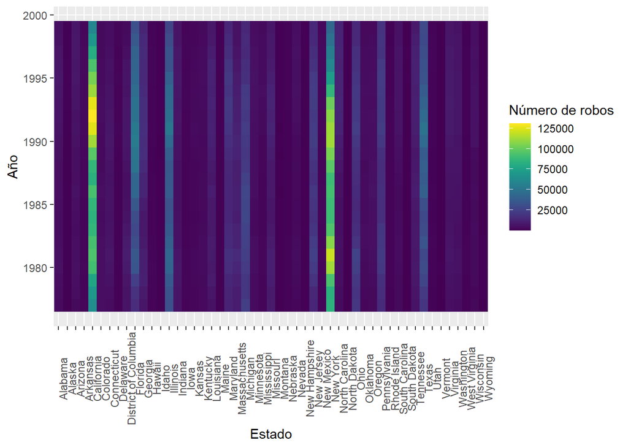

```r
ggplot(data = df) + geom_tile(aes(x = state, y = year, fill = robbery)) +
  scale_fill_viridis() + labs(x = "Estado", y = "Año", fill = "Número de robos") + theme(axis.text.x = element_text(angle = 90))
```

### 1.2

**Generar una gráfica para visualizar en cada año, el número total de cada tipo de crimen También se pide generar una tabla con esta información**

```r
crimen <- df %>%
  group_by(year) %>%
  summarise(violent = sum(violent),
            murder = sum(murder),
            robbery = sum(robbery)) %>%
pivot_longer(cols = c(violent, murder, robbery),
             names_to = 'crime',
             values_to = 'number')
head(crimen)
```

```
## # A tibble: 6 × 3
##    year crime    number
##   <int> <chr>     <int>
## 1  1977 violent 1045270
## 2  1977 murder    19496
## 3  1977 robbery  417430
## 4  1978 violent 1105759
## 5  1978 murder    20003
## 6  1978 robbery  433402
```

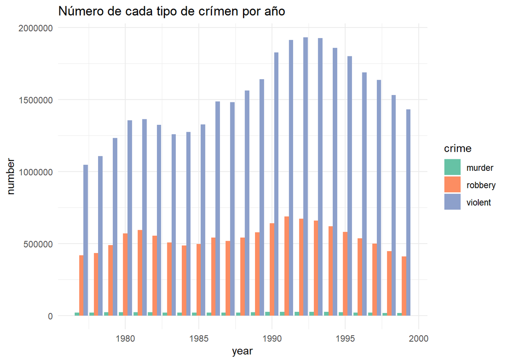

```r
ggplot(crimen, aes(x = year, y = number, fill = crime)) +
  geom_col(stat = "identity", position = "dodge") +
  theme_minimal() +
  scale_fill_brewer(palette = "Set2") +
  labs(title = "Número de cada tipo de crímen por año")
```

### 1.3

**Generar una gráfica para visualizar en cada año, la proporción de cada tipo de crimen.**

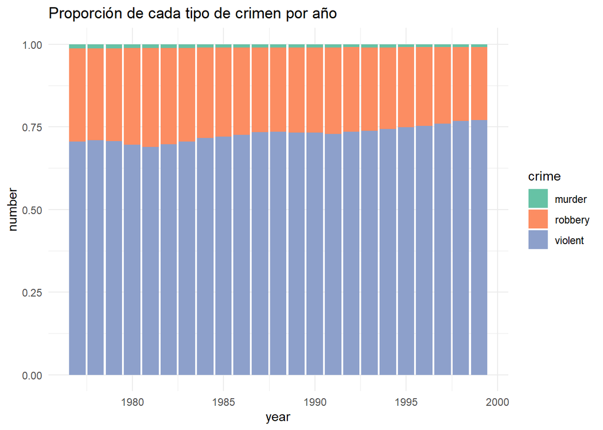

```r
ggplot(crimen, aes(x = year, y = number, fill = crime)) +
  geom_bar(stat = "identity", position = "fill") +
  theme_minimal() +
  scale_fill_brewer(palette = "Set2") +
  labs(title = "Proporción de cada tipo de crimen por año")
```

### 1.4

**Generar una imagen para visualizar el número de presos que hubo cada año entre 1980 y 1990 distinguiendo entre los estados de Alabama, Arizona y Florida.**

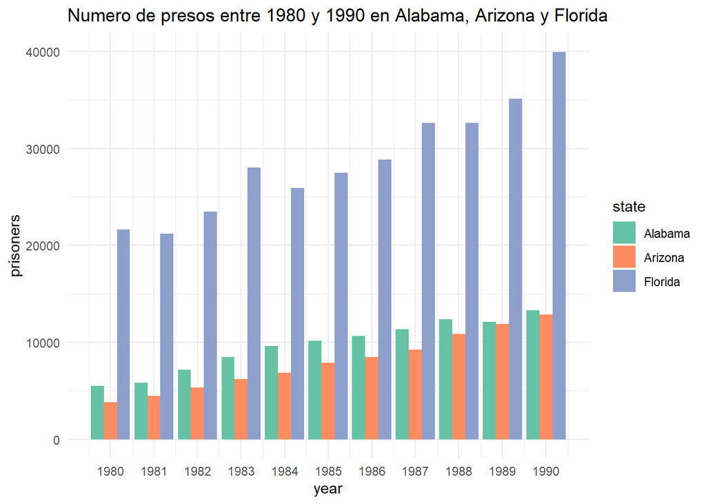

```r
presos <- df %>%
  filter(state %in% c('Alabama','Arizona','Florida'),
         year %in% seq(1980, 1990, 1))

ggplot(presos, aes(x = year, y = prisoners, fill = state)) +
  geom_col(stat = "identity", position = "dodge") +
  theme_minimal() +
  scale_fill_brewer(palette = "Set2") +
  scale_x_continuous(breaks = seq(1980, 1990, 1)) +
  labs(title = "Numero de presos entre 1980 y 1990 en Alabama, Arizona y Florida")
```

### 1.5

**¿El número de presos es diferente entre los 3 estados?**

```r
modelo <- aov(prisoners ~ state, data = presos)
anova(modelo)
```

```
## Analysis of Variance Table
##
## Response: prisoners
##           Df     Sum Sq    Mean Sq F value    Pr(>F)
## state      2 2943380502 1471690251  87.921 2.843e-13 ***
## Residuals 30  502160762   16738692
## ---
## Signif. codes:  0 '***' 0.001 '**' 0.01 '*' 0.05 '.' 0.1 ' ' 1
```

### 1.6

**Generar una imagen para visualizar la distribución del número de robos y prisioneros en cada año, comparando ambas variables simultáneamente.**

```r
distrib <- df %>%
  group_by(year, state) %>%
  summarise(robos = sum(robbery),
            prisioneros = sum(prisoners)) %>%
pivot_longer(cols = c(robos, prisioneros),
             names_to = "Tipo",
             values_to = "Número")
head(distrib)
```

```
## # A tibble: 6 × 4
## # Groups:   year [1]
##    year state   Tipo        Número
##   <int> <chr>   <chr>        <int>
## 1  1977 Alabama robos         3659
## 2  1977 Alabama prisioneros   3138
## 3  1977 Alaska  robos          391
## 4  1977 Alaska  prisioneros    254
## 5  1977 Arizona robos         3352
## 6  1977 Arizona prisioneros   3031
```

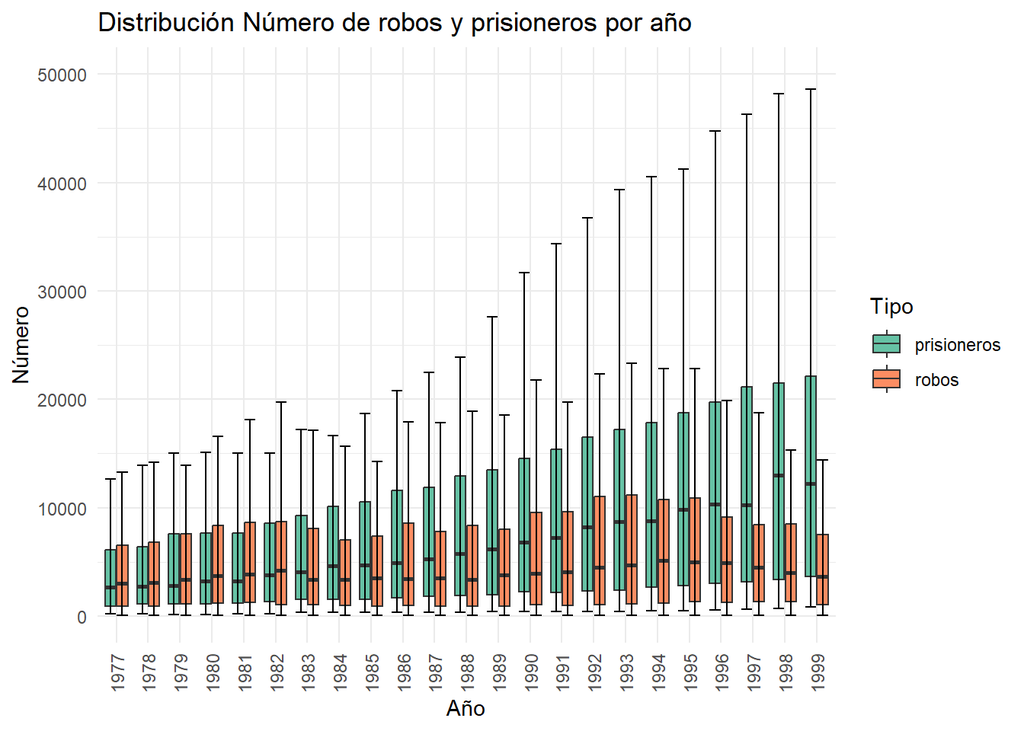

```r
ggplot(distrib, aes(x = as.factor(year), y = Número, fill = Tipo)) +
  geom_boxplot(outlier.shape = NA) +
  scale_y_continuous(limits = c(0, 50000)) +
  stat_boxplot(geom = "errorbar") +
  theme_minimal() +
  scale_fill_brewer(palette = "Set2") +
  labs(x = "Año", title = "Distribución Número de robos y prisioneros por año") +
  theme(axis.text.x = element_text(angle = 90, vjust = 0.5, hjust = 1))
```

### 1.7

**Ahora nos vamos a centrar en el estado de Nevada. Queremos saber que tipo de crimen tiene mayor correlación con el número de prisioneros. Para realizar el test estadístico correpondiente se puede utilizar la función `cor.test()`. Finalmente, generar una gráfica para visualizar la correlación del ese tipo de crimen con el número de prisioneros**

```r
data4 <- df %>%
  filter(state == "Nevada")

c_v <- cor.test(data4$violent,data4$prisoners)
c_m <- cor.test(data4$murder,data4$prisoners)
c_r <- cor.test(data4$robbery,data4$prisoners)

c_v
```

```
##
##  Pearson's product-moment correlation
##
## data:  data4$violent and data4$prisoners
## t = 5.941, df = 21, p-value = 6.757e-06
## alternative hypothesis: true correlation is not equal to 0
## 95 percent confidence interval:
##  0.5635418 0.9077398
## sample estimates:
##       cor
## 0.7918115
```

```r
c_m
```

```
##
##  Pearson's product-moment correlation
##
## data:  data4$murder and data4$prisoners
## t = 3.4886, df = 21, p-value = 0.00219
## alternative hypothesis: true correlation is not equal to 0
## 95 percent confidence interval:
##  0.2579251 0.8145511
## sample estimates:
##       cor
## 0.6057279
```

```r
c_r
```

```
##
##  Pearson's product-moment correlation
##
## data:  data4$robbery and data4$prisoners
## t = 4.5635, df = 21, p-value = 0.000169
## alternative hypothesis: true correlation is not equal to 0
## 95 percent confidence interval:
##  0.4137786 0.8659570
## sample estimates:
##       cor
## 0.7056285
```

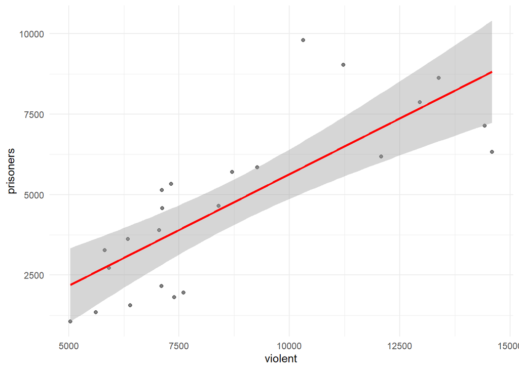

```r
ggplot(data4, aes(x = violent, y = prisoners)) +
  geom_point(alpha = 0.5) +
  geom_smooth(method = "lm", color = "red") +
  theme_minimal()
```

### 1.8

**Se quiere comprobar para cada estado si el número de asesinatos es diferente entre los años pasados (1977-1988) y los años más recientes(1989-1999). Finalmente, se pide visualizar estos resultados en una gráfica**

```r
data5 <- df

data5$periodo <- ifelse(data5$year <= 1988, "Pasado", "Reciente")

estados <- unique(data5$state)

p_value <- vector()

for(i in 1:length(estados)) {
  estado <- estados[i]
  datos <- data5[data5$state == estado,]

  test <- t.test(murder ~ periodo, data = datos)
  p_value[i] <- test$p.value
}

p_value
```

```
##  [1] 9.578223e-01 1.349303e-01 3.241205e-04 7.965545e-03 1.857344e-01
##  [6] 3.113021e-01 9.834235e-02 1.200830e-01 5.008000e-08 9.049411e-02
## [11] 8.940171e-01 1.028578e-01 5.763205e-01 5.641268e-02 1.443979e-02
## [16] 5.516214e-03 9.616378e-03 2.197586e-03 2.535522e-02 2.435030e-01
## [21] 2.724970e-14 5.235851e-01 1.163981e-01 3.746245e-10 3.893263e-01
## [26] 6.973850e-01 3.578372e-01 9.632231e-01 4.591906e-03 8.837421e-01
## [31] 1.692382e-02 3.982233e-01 4.498665e-01 6.619229e-04 2.823616e-01
## [36] 1.045403e-01 2.213177e-01 4.439830e-01 6.466677e-02 8.720961e-01
## [41] 6.588592e-01 6.221940e-18 1.776082e-02 8.023783e-02 2.890464e-01
## [46] 6.312382e-01 4.700187e-03 5.031357e-02 2.369216e-01 2.279349e-18
## [51] 1.047173e-08
```

```r
bonferroni <- p.adjust(p_value, method = "bonferroni")
BH <- p.adjust(p_value, method = "BH")

bonferroni
```

```
##  [1] 1.000000e+00 1.000000e+00 1.653015e-02 4.062428e-01 1.000000e+00
##  [6] 1.000000e+00 1.000000e+00 1.000000e+00 2.554080e-06 1.000000e+00
## [11] 1.000000e+00 1.000000e+00 1.000000e+00 1.000000e+00 7.364292e-01
## [16] 2.813269e-01 4.904353e-01 1.120769e-01 1.000000e+00 1.000000e+00
## [21] 1.389735e-12 1.000000e+00 1.000000e+00 1.910585e-08 1.000000e+00
## [26] 1.000000e+00 1.000000e+00 1.000000e+00 2.341872e-01 1.000000e+00
## [31] 8.631148e-01 1.000000e+00 1.000000e+00 3.375807e-02 1.000000e+00
## [36] 1.000000e+00 1.000000e+00 1.000000e+00 1.000000e+00 1.000000e+00
## [41] 1.000000e+00 3.173189e-16 9.058020e-01 1.000000e+00 1.000000e+00
## [46] 1.000000e+00 2.397095e-01 1.000000e+00 1.000000e+00 1.162468e-16
## [51] 5.340580e-07
```

```r
BH
```

```
##  [1] 9.632231e-01 2.372912e-01 2.361449e-03 3.124945e-02 3.157485e-01
##  [6] 4.410112e-01 2.050598e-01 2.187227e-01 4.256800e-07 2.006609e-01
## [11] 9.305075e-01 2.050598e-01 6.835429e-01 1.438523e-01 4.909528e-02
## [16] 2.344391e-02 3.503109e-02 1.245299e-02 7.183979e-02 3.763228e-01
## [21] 4.632449e-13 6.357819e-01 2.187227e-01 4.776462e-09 5.207535e-01
## [26] 7.731877e-01 4.932351e-01 9.632231e-01 2.179177e-02 9.305075e-01
## [31] 5.328247e-02 5.207535e-01 5.595901e-01 4.219759e-03 4.211818e-01
## [36] 2.050598e-01 3.641033e-01 5.595901e-01 1.570479e-01 9.305075e-01
## [41] 7.467070e-01 1.586595e-16 5.328247e-02 1.860059e-01 4.211818e-01
## [46] 7.316624e-01 2.179177e-02 1.350522e-01 3.763228e-01 1.162468e-16
## [51] 1.068116e-07
```

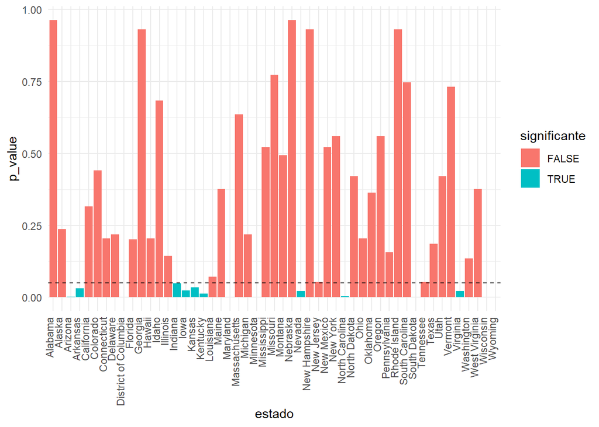

```r
data6 <- data.frame(estado = estados, p_value = BH)
data6$significante <- data6$p_value < 0.05

ggplot(data6, aes(x = estado, y = p_value, fill = significante)) +
  geom_bar(stat = "identity") +
  theme_minimal() +
  geom_hline(yintercept = 0.05, color = "black", linetype = "dashed") +
  theme(axis.text.x = element_text(angle = 90, hjust = 1, vjust = 0))
```

# Ejercicio 2

Este ejercicio corresponde al examen del curso 22/23. La única diferencia es que se han modificado los enunciado para que no sea “tan fácil”.

Los datos de este ejercicio tratan sobre mensajes, distinguiendo entre mensajes deseados “HAM” y mensajes no deseados “SPAM”. La base de datos incluye el contenido de cada mensaje.

**cargar los archivos spam.csv**

```r
data1 <- read.csv('C:/Users/enriq/Desktop/Master/Data Science (MIB)/Preparación Primer Parcial/Ejercicios Examen/data/spam.csv',header = T, sep = ',', stringsAsFactors = F,check.names = F, fileEncoding = 'latin1')

# Delete columns 3,4 and 5 (son columnas vacias)
data1 <- data1[,1:2]
colnames(data1) <- c('Class', 'Message')
head(data1)
```

```
##   Class
## 1   ham
## 2   ham
## 3  spam
## 4   ham
## 5   ham
## 6  spam
##                                                                                                                                                       Message
## 1                                             Go until jurong point, crazy.. Available only in bugis n great world la e buffet... Cine there got amore wat...
## 2                                                                                                                               Ok lar... Joking wif u oni...
## 3 Free entry in 2 a wkly comp to win FA Cup final tkts 21st May 2005. Text FA to 87121 to receive entry question(std txt rate)T&C's apply 08452810075over18's
## 4                                                                                                           U dun say so early hor... U c already then say...
## 5                                                                                               Nah I don't think he goes to usf, he lives around here though
## 6        FreeMsg Hey there darling it's been 3 week's now and no word back! I'd like some fun you up for it still? Tb ok! XxX std chgs to send, å£1.50 to rcv
```

**Modificar la columna ‘Message’ para que todas las letras estén en minúsculas. Se puede utilizar la función `tolower()`. También se pide quitar los signos de puntuación, dígitos y “stop words”. Para esto utilizar la librería `tm`.**

Los “stop words” son palabras que no añaden información. En el campo de Procesamiento del Lenguaje (NPL) es uno de las etapas iniciales. Aunque parezca que se pierde información, la realidad es que estas palabras son inecesarias.

```r
data2 <- data1
data2$Message <- tolower(data2$Message)
data2$Message <- removePunctuation(data2$Message)
data2$Message <- removeNumbers(data2$Message)
data2$Message <- removeWords(data2$Message,"english")
head(data2)
```

```
##   Class
## 1   ham
## 2   ham
## 3  spam
## 4   ham
## 5   ham
## 6  spam
##                                                                                                                                    Message
## 1                                   go until jurong point crazy available only in bugis n great world la e buffet cine there got amore wat
## 2                                                                                                                  ok lar joking wif u oni
## 3             free entry in  a wkly comp to win fa cup final tkts st may  text fa to  to receive entry questionstd txt ratetcs apply overs
## 4                                                                                              u dun say so early hor u c already then say
## 5                                                                              nah i dont think he goes to usf he lives around here though
## 6 freemsg hey there darling its been  weeks now and no word back id like some fun you up for it still tb ok xxx std chgs to send å£ to rcv
```

**Eliminar en la columna ‘Message’ las palabras que tengan menos de 3 letras**

```r
data2$Message <- sapply(strsplit(data2$Message, " "), function(x){
  paste(x[nchar(x) >= 3], collapse = " ")
})
head(data2)
```

```
##   Class
## 1   ham
## 2   ham
## 3  spam
## 4   ham
## 5   ham
## 6  spam
##                                                                                                        Message
## 1                    until jurong point crazy available only bugis great world buffet cine there got amore wat
## 2                                                                                           lar joking wif oni
## 3           free entry wkly comp win cup final tkts may text receive entry questionstd txt ratetcs apply overs
## 4                                                                           dun say early hor already then say
## 5                                                             nah dont think goes usf lives around here though
## 6 freemsg hey there darling its been weeks now and word back like some fun you for still xxx std chgs send rcv
```

### 2.1

**Calcular para cada mensaje la longitud media de las palabras que forman el mensaje. Para esto, primero vamos a transformar cada palabra en su forma base (conocido como lema). Esto se puede hacer utilizando la función `lemmatize_words()`. Para calcular la media no se deben tener en cuenta palabras base con longitud menor a 3.**

A modo de ejemplo de como funciona esta función:

```r
lemmatize_words("driving")
```

```
## [1] "drive"
```

```r
# driving -> drive
```

```r
data2$Message <- sapply(data2$Message, function(x){
  palabra <- strsplit(x," ")[[1]]
  lemas <- lemmatize_words(palabra)
  paste(lemas, collapse = " ")
})

data2$Media <- sapply(data2$Message, function(x){
  palabra <- strsplit(x," ")[[1]]
  filtradas <- palabra[nchar(palabra) >= 3]
  mean(nchar(filtradas))
})
head(data2)
```

```
##   Class
## 1   ham
## 2   ham
## 3  spam
## 4   ham
## 5   ham
## 6  spam
##                                                                                                     Message
## 1                 until jurong point crazy available only bugis great world buffet cine there get amore wat
## 2                                                                                          lar joke wif oni
## 3        free entry wkly comp win cup final tkts may text receive entry questionstd txt ratetcs apply overs
## 4                                                                        dun say early hor already then say
## 5                                                               nah do think go usf life around here though
## 6 freemsg hey there darling its be week now and word back like some fun you for still xxx std chgs send rcv
##      Media
## 1 5.000000
## 2 3.250000
## 3 4.823529
## 4 4.000000
## 5 4.428571
## 6 3.904762
```

### 2.2

**¿la longitud media de las palabras que forman los mensajes (calculado en el apartado anterior) es diferente para los mensajes tipo “Spam” y tipo “Ham”? Realiza una gráfica para mostrar esta comparación.**

```r
ham <- shapiro.test(data2$Media[data2$Class == "ham"])
spam <- shapiro.test(data2$Media[data2$Class == "spam"])
if(ham$p.value < 0.05 & spam$p.value < 0.05) {
  cat("Ambos grupos son normales -> Usar t-test")
} else {
  cat("Al menos uno de los grupos no es normal -> Usar Wilcoxon-test")
}
```

```
## Ambos grupos son normales -> Usar t-test
```

```r
ham <- data2$Media[data2$Class == "ham"]
spam <- data2$Media[data2$Class == "spam"]
test <- t.test(spam,ham)
if(test$p.value < 0.05) {
  cat("Longitud media diferente para cada tipo de mensaje")
} else {
  cat("Longitud media no diferente para cada tipo de mensaje")
}
```

```
## Longitud media diferente para cada tipo de mensaje
```

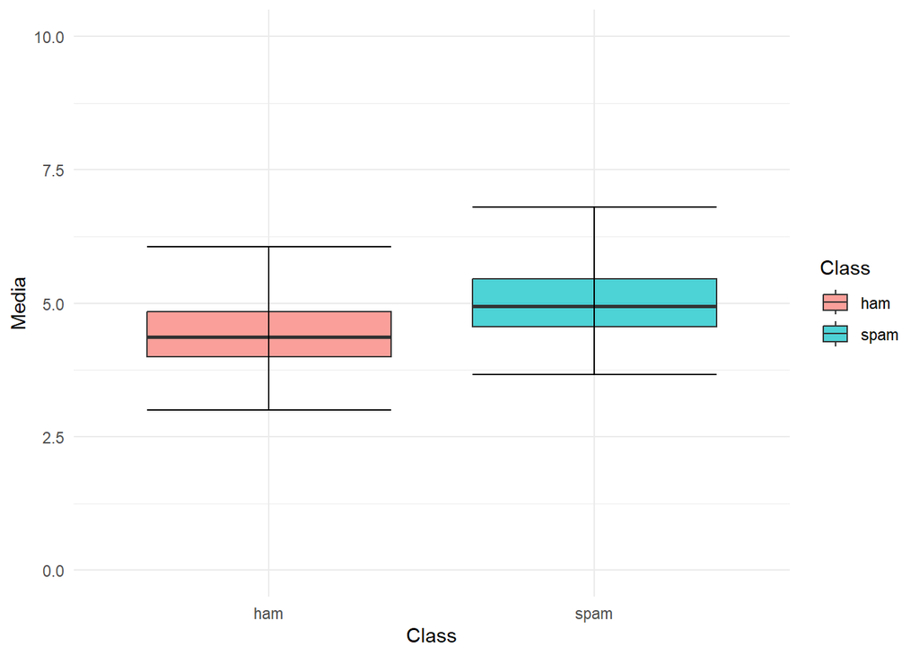

```r
ggplot(data2, aes(x = Class, y = Media, fill = Class)) +
  geom_boxplot(alpha = 0.7, outlier.shape = NA) +
  stat_boxplot(geom = "errorbar") +
  scale_y_continuous(limits = c(0,10)) +
  theme_minimal()
```

### 2.3

**Se pide construir una matriz Y que contenga para cada mensaje (fila) la cantidad de veces que aparece cada palabra (columnas). La matriz Y tendrá por tanto 5479 filas (número de mensajes) y xxx columnas (siendo xxx el número de palabras distintas**

```r
tokens <- str_split(data2$Message, " ")
palabras <- unique(unlist(tokens))
Y <- matrix(nrow = length(data2$Message), ncol = length(palabras))
colnames(Y) <- palabras
rownames(Y) <- paste0("msg_", seq_along(data2$Message))
for(i in 1:length(data2$Message)){
  mensaje <- tokens[[i]]
  conteo <- table(mensaje)
  palabras_en_mensaje <- names(conteo)
  indices <- match(palabras_en_mensaje, palabras)  # convertir nombres a índices
  Y[i, indices] <- as.numeric(conteo)
}
Y[is.na(Y)] <- 0
```

**Crear una matriz X que resulte de eliminar palabras que tengan una frecuencia menor a 50. Es decir, palabras que en total hayan aparecido menos de 50 veces. La matriz resultante debe tener 5479 filas y 119 columnas.**

```r
idx <- colSums(Y)>50
X <- Y[,idx]
```

**Realizar una gráfica en 2D que resuma, en la medida de lo posible, el máximo de información que contienen las columnas de la matriz X. En la gráfica debe distinguir entre los mensajes tipo “ham” y tipo “spam”.**

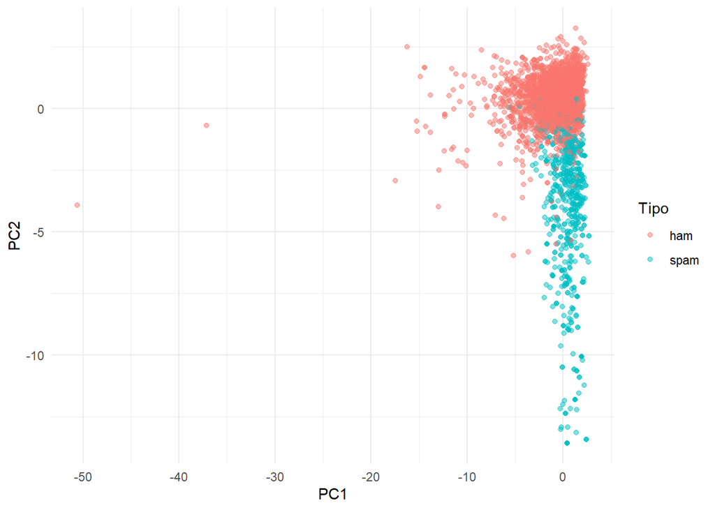

```r
PCA <- prcomp(X, center = T, scale = T)
componentes <- data.frame(PC1 = PCA$x[,1], PC2 = PCA$x[,2], Tipo = data2$Class)

ggplot(componentes, aes(x = PC1, y = PC2, color = Tipo)) +
  geom_point(alpha = 0.5) +
  theme_minimal()
```

**Con la información obtenida de la gráfica anterior, ¿hay algún eje de la gráfica donde se pueda distinguir entre los mensajes tipo “ham” y tipo “spam”? En caso de que sea así, ¿que variables de X son las que más influyen en ese eje?**

```r
loadings_PC2 <- PCA$rotation[,2]
top5 <- names(sort(abs(loadings_PC2), decreasing = T)[1:5])
top5
```

```
## [1] "prize"  "call"   "claim"  "win"    "urgent"
```

```r
loadings_PC2[top5]
```

```
##      prize       call      claim        win     urgent
## -0.3055888 -0.2754931 -0.2744218 -0.2383174 -0.2280172
```

**¿Están estas 5 palabras relacionadas con que el mensaje sea “spam” o sea “ham”?**

```r
for(palabra in top5) {
  tabla <- table(X[, palabra] > 0, componentes$Tipo)
  resultado <- fisher.test(tabla)
  cat("\n", palabra, "- p-valor:", resultado$p.value)
}
```

```
##
##  prize - p-valor: 1.056683e-77
##  call - p-valor: 4.715191e-154
##  claim - p-valor: 5.465179e-99
##  win - p-valor: 7.644926e-97
##  urgent - p-valor: 1.262917e-52
```

# Ejercicio 3

Los datos de este ejercicio contiene información de los partidos de la liga 2018-2019.

**cargar los datos**

```r
dataF <- read.csv('C:/Users/enriq/Desktop/Master/Data Science (MIB)/Preparación Primer Parcial/Ejercicios Examen/data/season-1819_csv.csv',header = T, sep = ',', stringsAsFactors = F,check.names = F)
```

### 3.1

**Se pide evaluar para cada equipo si el hecho de jugar de local aumenta las posibilidades de ganar. Dar una lista, con una tasa de falsos positivos del 10%, de equipos en los que jugar de local influye en el hecho de ganar**

```r
equipos <- unique(dataF$HomeTeam)
lista <- c()

evaluacion <- function(equipo) {

  tabla <- matrix(ncol = 2, nrow = 2)
  rownames(tabla) <- c("Win","Not Win")
  colnames(tabla) <- c("Home","Away")

  idx_h <- which(dataF$HomeTeam == equipo)
  tabla[1,1] <- sum(dataF$FTR[idx_h] == "H")
  tabla[2,1] <- sum(dataF$FTR[idx_h] %in% c("A","D"))

  idx_a <- which(dataF$AwayTeam == equipo)
  tabla[1,2] <- sum(dataF$FTR[idx_a] == "A")
  tabla[2,2] <- sum(dataF$FTR[idx_a] %in% c("H","D"))

  test <- fisher.test(tabla)

  if(test$p.value < 0.1) {
    return(equipo)
  }
  return(NULL)
}

for(i in 1:length(equipos)) {
  equipo <- equipos[i]
  resultado <- evaluacion(equipo)
  if(!is.null(resultado)) {
    lista <- c(lista, resultado)
  }
}

print(lista)
```

```
## [1] "Celta"      "Eibar"      "Getafe"     "Ath Madrid" "Espanol"
## [6] "Sevilla"
```

### 3.2

**Se pide generar una gráfica en la que se muestre para cada equipo la proporción de victorias como local y como visitante.**

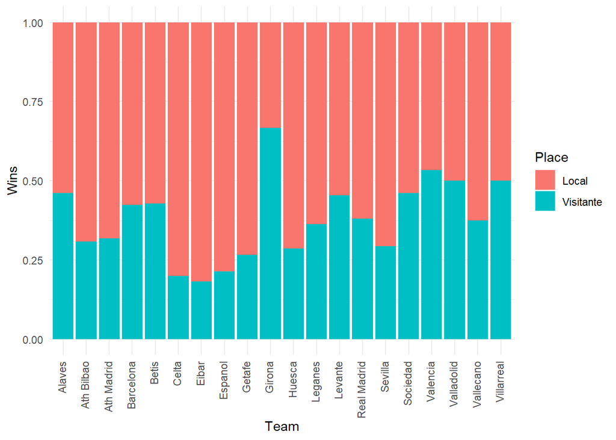

```r
data7 <- dataF %>%
  pivot_longer(cols = c(HomeTeam,AwayTeam), names_to = "Place_Type", values_to = "Team") %>%
  mutate(Win = case_when(Place_Type == "HomeTeam" & FTR == "H" ~ 1,
                         Place_Type == "AwayTeam" & FTR == "A" ~ 1,
                         .default = 0),
         Place = ifelse(Place_Type == "HomeTeam", "Local", "Visitante")) %>%
  group_by(Team, Place) %>%
  summarise(Wins = sum(Win), .groups = "drop")

ggplot(data7, aes(x = Team, y = Wins, fill = Place)) +
  geom_bar(stat = "identity", position = "fill") +
  theme_minimal() +
  theme(axis.text.x = element_text(angle = 90, hjust = 1, vjust = 0.3))
```

**Realizar también la gráfica mostrando el número total de victorias, distinguiendo entre las victorias como local y como visitante**

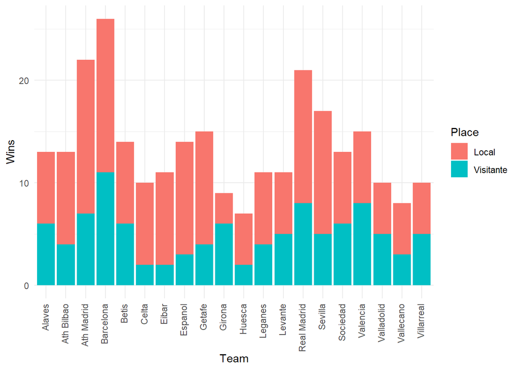

```r
ggplot(data7, aes(x = Team, y = Wins, fill = Place)) +
  geom_bar(stat = "identity") +
  theme_minimal() +
  theme(axis.text.x = element_text(angle = 90, hjust = 1, vjust = 0.3))
```

### 3.3

**Las siguiente variables muestran caracteristicas sobre el rendimiento del equipo que jugó como visitante**

```r
cols1 <- c('AS', 'AST','AC', 'AF', 'FTAG', 'HTAG', 'AY')
```

**Se pide generar una tabla que contenga para cada equipo esta información, sumando el rendimiento en cada partido**

```r
rendimiento_visitante <- dataF %>%
  group_by(AwayTeam) %>%
  summarise(AS = sum(AS),
            AST = sum(AST),
            AC = sum(AC),
            AF = sum(AF),
            FTAG = sum(FTAG),
            HTAG = sum(HTAG),
            AY = sum(AY))
head(rendimiento_visitante)
```

```
## # A tibble: 6 × 8
##   AwayTeam      AS   AST    AC    AF  FTAG  HTAG    AY
##   <chr>      <int> <int> <int> <int> <int> <int> <int>
## 1 Alaves       185    52    56   272    20     9    51
## 2 Ath Bilbao   148    55    52   294    15     9    57
## 3 Ath Madrid   205    74   109   244    23    10    51
## 4 Barcelona    227   105    91   195    39    19    44
## 5 Betis        186    80    84   208    19     4    42
## 6 Celta        209    73    65   216    22     9    42
```

**Realizar una gráfica en 2D que maximice est información**

```r
PCA <- prcomp(rendimiento_visitante[,-1], center = T, scale. = T)
summary(PCA)
```

```
## Importance of components:
##                          PC1   PC2    PC3     PC4    PC5     PC6     PC7
## Standard deviation     1.928 1.171 1.0191 0.63324 0.5681 0.32635 0.20480
## Proportion of Variance 0.531 0.196 0.1484 0.05728 0.0461 0.01521 0.00599
## Cumulative Proportion  0.531 0.727 0.8754 0.93269 0.9788 0.99401 1.00000
```

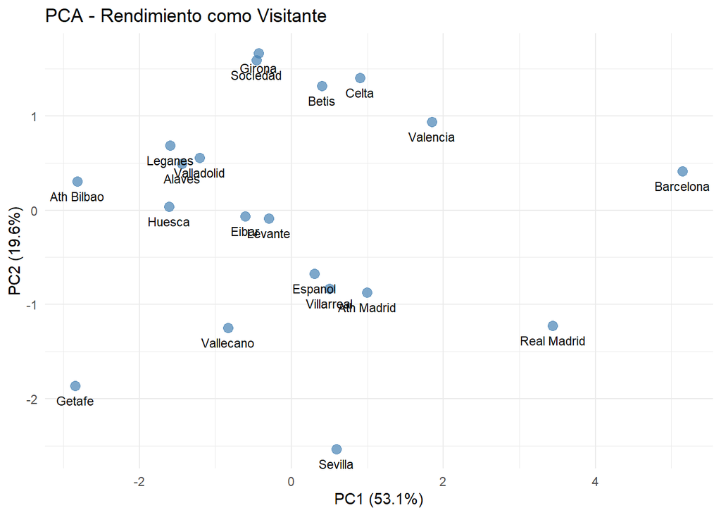

```r
comps <- data.frame(PC1 = PCA$x[,1],
                    PC2 = PCA$x[,2],
                    Equipo = rendimiento_visitante$AwayTeam)

ggplot(comps, aes(x = PC1, y = PC2, label = Equipo)) +
  geom_point(size = 3, alpha = 0.7, color = "steelblue") +
  geom_text(hjust = 0.5, vjust = 2, size = 3) +
  labs(title = "PCA - Rendimiento como Visitante",
       x = paste0("PC1 (", round(summary(PCA)$importance[2,1]*100, 1), "%)"),
       y = paste0("PC2 (", round(summary(PCA)$importance[2,2]*100, 1), "%)")) +
  theme_minimal()
```

# Ejercicio 4

Este ejercicio corresponde al examen del curso 23/24. Se han modificado un poco las preguntas para que no sea “tan fácil”.

### 4.1

**cargar los datos Residuos.csv.**  
**Eliminar la segunda columna “Total Nacional”**  
**Eliminar filas que contengan “missing values”**  
**Cambiar el nombre del data.frame a ‘Tipo’, ‘Comunidad’, ‘Año’, ‘Total’**  
**1 punto**

```r
dt <- read.csv("C:/Users/enriq/Desktop/Master/Data Science (MIB)/Preparación Primer Parcial/Ejercicios Examen/data/Residuos.csv", header = T, sep = "\t")

dt1 <- dt[,-2]
dt1[dt1 == ''] <- NA
dt1 <- na.omit(dt1)
colnames(dt1) <- c("Tipo","Comunidad","Año","Total")
```

### 4.2

**Convierte la variable ‘Total’ en numérica, teniendo en cuenta que es necesario eliminar los “.”**  
**Elimina el código numérico en las columnas ‘Tipo’ y ‘Comunidad’**

```r
dt1$Total <- str_replace_all(dt1$Total, "\\.", "")
dt1$Total <- as.numeric(dt1$Total)
dt1$Tipo <- str_split_fixed(dt1$Tipo, " ", 2)
dt1$Tipo <- dt1$Tipo[,2]
dt1$Comunidad <- str_split_fixed(dt1$Comunidad, " ", 2)
dt1$Comunidad <- dt1$Comunidad[,2]
```

**Finalmente, ejecuta el siguiente código para tener los nombres de las comunidades más cómodos de leer**  
**2 puntos**

```r
dt1$Comunidad[dt1$Comunidad =='Madrid, Comunidad de']= 'Madrid'
dt1$Comunidad[dt1$Comunidad =='Murcia, Región de']= 'Murcia'
dt1$Comunidad[dt1$Comunidad =='Asturias, Principado de']= 'Asturias'
dt1$Comunidad[dt1$Comunidad =='Navarra, Comunidad Foral de']= 'Navarra'
dt1$Comunidad[dt1$Comunidad =='Balears, Illes']= 'Islas Baleares'
dt1$Comunidad[dt1$Comunidad =='Rioja, La']= 'La Rioja'
```

### 4.3

**Resumir datos anteriores por año y comunidad, obteniendo para cada comunidad la cantidad total de residuos**  
**Leer el archivo ‘Poblacion.csv’**  
**Normalizar la cantidad de residuos por la población de la comunidad. Unidades: Toneladas/persona.**  
**Realizar un gráfico para las siguientes comunidades:**

```r
idx <- iso <- c('Madrid', 'Murcia', 'País Vasco', 'Islas Baleares', 'Cataluña', 'Navarra')
```

**En el que se muestre los los residuos normalizados por comunidad y año**

```r
dt2 <- dt1 %>%
  group_by(Año, Comunidad) %>%
  summarise(Residuos = sum(Total))
```

[output not shown]

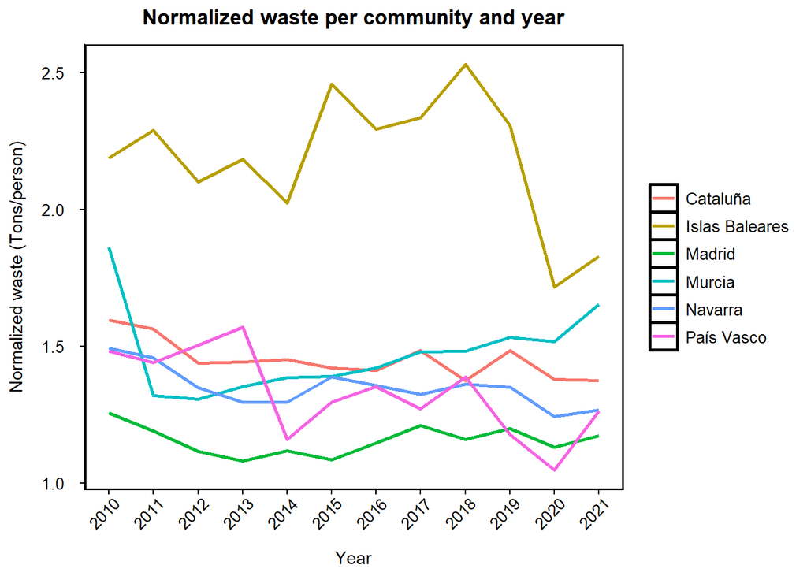

```r
dt3 <- read.csv("C:/Users/enriq/Desktop/Master/Data Science (MIB)/Preparación Primer Parcial/Ejercicios Examen/data/Poblacion.csv", header = T, sep = ",")

dt3 <- dt3[,-1]

ResiduosNorm <- dt2 %>%
  left_join(dt3, by = c("Año", "Comunidad")) %>%
  mutate(Residuos_Normalizados = Residuos/Total) %>%
  select(Año, Comunidad, Residuos_Normalizados)

ResiduosNorm_Filtrado <- ResiduosNorm %>%
  filter(Comunidad %in% idx)

ggplot(ResiduosNorm_Filtrado, aes(x = Año, y = Residuos_Normalizados, color = Comunidad)) +
  geom_line(linewidth=1)+ theme_classic()+
  theme(legend.title=element_blank(),
        legend.text = element_text(size = 10),
        panel.grid.major = element_blank(),
        panel.grid.minor = element_blank(),
        panel.background = element_rect(colour = "black", linewidth = 1),
        axis.text.y = element_text(size = 10, margin=margin(0,10,0,0)),
        axis.text.x = element_text(size = 10,
                                   angle = 45, hjust = 0.9),
        axis.title.x = element_text(margin=margin(10,0,0,0)),
        axis.title.y = element_text(margin=margin(0,10,0,0)),
        plot.title = element_text(hjust = 0.5, margin=margin(0,0,10,0),
                                  face = 'bold'))+
  ggtitle('Normalized waste per community and year') +
  xlab('Year') + ylab('Normalized waste (Tons/person)') +
  scale_x_continuous(name='Year',
                     breaks=seq(2010,2021,1))
```

### 4.4

**Evaluar la tendencia lineal de los residuos a lo largo del tiempo para cada comunidad utilizando la prueba de correlación (calcular el p.value para cada comunidad)**  
**Identificar qué comunidades muestran una disminución significativa en los residuos a lo largo del tiempo (FDR <= 0.05)**  
**2 puntos**

```r
resultados <- ResiduosNorm %>%
  group_by(Comunidad) %>%
  summarise(correlación = cor(Año, Residuos_Normalizados, method = "pearson"),
            p_value = cor.test(Año, Residuos_Normalizados)$p.value)

resultados <- resultados %>%
  mutate(p_ajustado = p.adjust(p_value, method = "BH"))

comunidades_disminución <- resultados %>%
  filter(correlación < 0, p_ajustado <= 0.05) %>%
  arrange(p_ajustado)
```

### 4.5

En el apartado anterior estamos utilizando n=12 para la prueba de correlación. ¿Es eso suficiente para capturar una correlación negativa de 0.5, asumiendo alpha=0.05 y power=0.8.

```r
# Calculamos el tamaño de muestra necesario:
resultado <- pwr.r.test(
  r = -0.5, # Correlación que queremos detectar
  sig.level = 0.05, # Alpha
  power = 0.8, # Power (1 - beta)
  alternative = "less" # Correlación NEGATIVA (si fuera "greater" sería positiva y "two.sided" que es diferente de 0) (Pero esto es la hipótesis que estamos probando)
)
resultado
```

```
##
##      approximate correlation power calculation (arctangh transformation)
##
##               n = 22.60907
##               r = -0.5
##       sig.level = 0.05
##           power = 0.8
##     alternative = less
```

```r
cat("No es suficiente ya que se necesita como mínimo n =",resultado$n)
```

```
## No es suficiente ya que se necesita como mínimo n = 22.60907
```